# 構造的因果モデルの基礎 輪読 ＃2

第2章 準備

谷口友哉

2021/04/23

# 2.1 因果推論における確率的考え方

## 構造的因果モデルのフレームワーク

- 仮定

  データは何らかの物理的なデータ生成過程に  
  従って生成
  - 変数間に客観的な関数関係（構造方程式モデル）が存在
  - 関数関係：「原因と呼ばれる変数に値を代入すると結果と  
    呼ばれる変数に1つの値が出力されるが、  
    結果に値を代入しても原因に対する値は得られない」
- 自然科学分野だけでなく、医学・工学・社会科学・  
  人文科学的現象も議論の対象
- データ生成過程の存在を仮定  
  ➡︎直接的・間接的な因果関係や**共通原因の原理**を  
  確率モデルに反映させる第1ステップ

## 共通原因の原理（common cause principle）

No correlation without causation  
因果なく相関なし

$\quad$

If an improbable coincidence has occurred, there must exist a common cause (Reichenbach,1956,p.157)  
ありえない偶然の一致が起こった場合、  
共通の原因が存在しなければならない

## 因果関係の解明を拒む壁

- **不確実性**が存在
  - データが大量に得られても、そのデータから推測された  
    統計モデルが物理的なデータ生成過程を適切に記述したものであることを、データだけを用いて保証する術を我々が持たない
  - 本来決定論的に解明したい因果関係を決定論的に  
    評価することが困難
- 構造的因果モデルのフレームワークでは  
  不確実性を評価するために、  
  データ生成過程と確率・統計的な考え方が融合

# 2.2 事象の確率

## 試行と事象の定義

- 試行（trial）

  母集団からデータを採取するために行う実験や観測
- 確率試行（stochastic trial）

  データを採取する際、起こりうる結果の全体は  
  概ね分かるが、その中のどれが観測できるのかを  
  あらかじめ知ることができない実験や観測
- 標本空間（sample space）,全事象（certain event）

  確率試行を行った時に起こりうる結果（要素）の  
  全体：$\Omega$ で表記
- 事象（event）

  標本空間の部分集合:  
  A,B,C…のように大文字アルファベットで表記

## 事象の種類

和事象（union of events）：$A\cup B$  
・事象A,Bの両方に含まれる要素を全て合わせたもの

積事象（intersection of events）：$A\cap B$  
・事象A,Bの両方に含まれる要素全てからなる  
$\;\:\:$標本空間$\Omega$ の部分集合

差事象（difference of events）：$A\backslash B$  
・事象Aから事象Bに含まれる要素全てを取り除いた後に  
$\;\:\:$残ったAの要素全体からなる集合

余事象（complement of an events）：$A^{c}$  
・$\Omega\backslash A$ を意味する

空集合（empty events）：$\phi$  
・$\Omega$ の要素を全く持たない集合

排反（disjoint,exclusive）  
・$A\cap B$ が空集合である時

## 例題：事象

- 標本空間:a,b,c,dを要素とする$\Omega=\bigl\{a,b,c,d\bigr\}$
- $\Omega$ の部分集合$A=\bigl\{a,b\bigr\}$,$B=\bigl\{b,c\bigr\}$
- 和事象、積事象、差事象、余事象は

$$A\cup B=\bigl\{a,b,c\bigr\},A\cap B=\bigl\{b\bigr\},\\
A\backslash B=\bigl\{a\bigr\},A^{c}=\bigl\{c,d\bigr\}
\tag{2.1}$$

## 確率（probability）

確率とは標本空間$\Omega$の部分集合で定義された関数$pr(\cdot)$

- ある事象Aが起こる（Aの要素が観測される）確率を$pr(A)$と表記
- 次の3つを満たす

$$0\leq pr(A)\leq1,\quad A\subset \Omega\tag{2.2}$$

$$pr(\Omega)=1\tag{2.3}$$

$$A\cap B = \phi\Rightarrow pr(A\cup B) = pr(A) + pr(B) \tag{2.4}$$

- 積事象$A\cap B,A\cap B^c$ は排反であることから、

$$\begin{aligned}
pr(A) &=pr\bigl((A\cap B)\cup (A\cap B^c)\bigr)\\
&=pr(A\cap B) + pr(A\cap B^c)
\end{aligned}
\tag{2.5}$$

## 全確率の公式（law of total probability）

- より一般に、$B_i(i=1,\:_\cdots,n)$ を互いに排反で標本空間$\Omega$ を完全に分割する事象、つまり$\Omega = B_1\cup_\cdots\cup B_n$で  
  かつ$i ≠j\:(i,j = 1,_\cdots,n)$ に対して積事象$B_i\cap B_j$ が  
  空集合となる事象のある集まりとする。このとき

$$\begin{aligned}
A &= A\cap\Omega\\
&= A\cap( B_1\cup_\cdots\cup B_n)\\
&= (A\cap B_1)\cup_\cdots\cup(A\cap B_n)
\end{aligned}
\tag{2.6}$$

- つまり$pr(A)$は$pr(A\cap B_i)\:(i=1,_\cdots n)$ を用いて

$$\begin{aligned}
pr(A) &= pr(A\cap\Omega)\\
&= pr\bigl((A\cap B_1)\cup_\cdots\cup(A\cap B_n)\bigr)\\
&= \sum_{i=1}^{n}pr(A\cap B_i)
\end{aligned}
\tag{2.7}$$

- (2.7)式を**全確率の公式**という

## 周辺確率（marginal probability）

(2.7)式において、積事象$A\cap B_i$ に対する確率$pr(A\cap B_i)$が与えられた時、全ての$B_i$ について確率を  
足し合わせることで得られる確率$pr(A)$ をAの**周辺確率**という

(cf) 事象$A$とその余事象$A^c$のどちらか1つは必ず起きることから(2.5)式の$A,B$ を$\Omega,A$と置き直すことにより、

$$pr(A) + pr(A^c) = 1 \tag{2.8}$$

## 条件付き確率（conditional probability）

ある事象$B$ が起こるという条件の下でもう1つの事象$A$ が起こる確率：$pr(A|B)$

- $pr(B)>0$ であるとき、$pr(A|B)$を事象$B$ を与えた時の事象$A$ の条件付き確率という

$$pr(A|B) = \frac{pr(A\cap B)}{pr(B)} \tag{2.9}$$

## 乗法公式（product rule）{#2_2}

## 連鎖公式（chain rule）

## 事象の（周辺）独立性（(marginal) independence）

$$A \mathop{\,\perp\!\!\!\!\!\perp\,}B$$

## 事象の条件付き独立性（conditional independence）

# 2.3 確率変数

## 離散型確率変数

$$pr(X = x)\geq0,\quad\sum_{x}pr(X = x)=1\tag{2.19}$$

## 連続型確率変数

## 期待値（expectation）

# 2.4 確率変数ベクトル

## 多次元確率変数ベクトルへ拡張

## 確率変数の集合

## 同時（確率）密度関数（joint probability density function）

## （累積）同時分布関数（joint cumulative distribution function）

## 周辺分布関数と周辺確率密度関数

## 条件付き確率密度関数（conditional probability density function）

## 乗法公式 {#2_4}

## 乗法公式の拡張

- 逐次的因数分解（recursive factorization）,連鎖公式

## 確率変数どうしの（周辺）独立性

## 確率変数どうしの条件付き独立性

## 条件付き期待値と条件付き分散

## 共分散と条件付き共分散

## 相関係数と条件付き相関係数

- 線形構造方程式モデルにおいては  
  偏相関係数（partial correlation coefficient）と呼ばれる

## 相関係数の基本的な性質

## 共分散行列、相関行列、相互共分散行列

# 2.5 グラフォイド原理

## グラフォイド原理（graphoid axioms）

## 条件付き独立関係のルール

## ルールを視覚化

# 2.6 グラフ用語

## 構造的因果モデルでグラフを使う意義

- 構造的因果モデルに基づいた因果推論では、必ずしも  
  グラフを使わなければならないわけではない（第1.2節）
- パス解析が源泉
- 構造的因果モデルのフレームワークを構築した  
  Judea Pearl本人がベイジアンネットワークの体系を構築 ➡︎構造的因果モデルを扱った文献のほとんどで  
  有向グラフによる解釈

## グラフ用語の定義

グラフ $G$（graph）は頂点（vertex,node）集合 $\bf V$ と  
その直積集合$\bf V \times \bf V$の部分集合である矢線（arrow）  
あるいは有向辺（directed edge）の集合$\bf E$ によって、 $\bf G = (\bf V,\bf E)$ と表現される

## 割り当てられる矢線の種類

- 異なる2つの頂点 $\alpha,\beta\in \bf V$ $(\alpha \neq \beta)$ に対して、$(\alpha,\beta)$ と $(\beta,\alpha)$ を同一視し、$(\alpha,\beta) \in \bf E$ であるとき、以下の  
  3つのうちの少なくとも1つを割り当てる
1. $\alpha$ から $\beta$ への矢線: $\alpha \rightarrow \beta$
2. $\alpha$ と $\beta$ の双方向矢線（bidirected arrow）: $\alpha \leftrightarrow \beta$
3. $\beta$ から $\alpha$ への矢線: $\beta \rightarrow \alpha$
- ただし$(\alpha,\beta) \in \bf E$に割り当てられる矢線の数は最大で  
  3つ
  - 同じタイプの矢線は割り当てない
  - $\alpha$ から $\alpha$ 自身に向かう矢線は考えない

## 部分グラフ（subgraph）

頂点集合 $\bf V$ の部分集合$\bf V^*$と  
矢線の集合$\bf E$ の部分集合$\bf E^*$に対して、  
$\bf E^*$ に属する矢線の両端が $\bf V^*$ に属する時、  
グラフ $G^* = (\bf V^*,\bf E^*)$ を$\bf V^*$ から生成される  
$G$ の部分グラフという

## 親（parent）と子（child）

- $\alpha$ から $\beta$ への矢線 $\alpha \rightarrow \beta$ が 存在する時、  
  $\alpha$ は $\beta$ の**親**（先祖・非子孫）であるといい、  
  $\beta$ は $\alpha$ の**子**（子孫）であるという
  - $pa(\beta)$ : $\beta$ の親の集合
  - $ch(\alpha)$ : $\alpha$ の子の集合
- **配偶者**（spouse）: 双方向矢線が存在
- 根（root）,源点（source）: グラフ$\bf G$ の頂点で  
  それに向かう矢線がない
- 葉（leaf）,沈点（sink）: それから出る矢線を  
  持たない
- 例 $\alpha \leftarrow \beta \rightarrow \gamma$ では
  - $\beta$ は根、$\alpha,\gamma$ は葉

## 道（path）と有向道（directed path）

- 異なる頂点の列$\alpha_0,\alpha_1,\cdots,\alpha_n$において全ての  
  $i = 1,_\cdots,n$で$(\alpha_{i-1},\alpha_i) \in \bf E$であるとき、頂点の列  
  $\alpha_0,\alpha_1,\cdots,\alpha_n$ を$\alpha_0$と$\alpha_n$ の間の**道**という  
  このとき、$\alpha_0$と$\alpha_n$を**端点**（endpoint）という  
  $\alpha_0$と$\alpha_n$の間に道があるとき$\alpha_0$と$\alpha_n$は**連結している**（connect）という
- $\alpha_0$と$\alpha_n$の間の道において、全ての$i = 1,_\cdots,n$ に  
  対して$\alpha_{i-1} \rightarrow \alpha_i$であり$\alpha_i \rightarrow \alpha_{i-1}$や$\alpha_i \leftrightarrow \alpha_{i-1}$で  
  ないとき、つまり

$$\alpha_0 \rightarrow \alpha_1 \rightarrow \cdots \rightarrow\alpha_{n-1} \rightarrow \alpha_n\tag{2.52}$$
$\;\;\:$を$\alpha_0$ から $\alpha_n$ への**有向道**という

## バックドアパス（back door path）

- $\alpha_0$と$\alpha_n$の間の道で$\alpha_0$へ向かう矢線を含むものを  
  ($\alpha_0$からの）**バックドアパス**という
- 双方向矢線はバックドアパスの例の一つ
- 見方を変えれば、$\alpha_0$から$\alpha_n$への有向道も  
  $\alpha_n$からのバックドアパス

## 巡回閉路と非巡回有向グラフ

- 有向道$\alpha_0,\alpha_1,\cdots,\alpha_n$で$\alpha_0 = \alpha_n$を許す、つまり、

$$\alpha_0 \rightarrow \alpha_1 \rightarrow \cdots \rightarrow\alpha_{n-1} \rightarrow \alpha_0 \tag{2.53}$$

$\;\;\:$を**巡回閉路**（cycle）という

- 巡回閉路の存在しない有効グラフを**非巡回的**（acyclic）といい、  
  **非巡回的有向グラフ**（directed acyclic graph;**DAG**）と  
  よぶ

## DAGで登場する用語1

- $\alpha$ から $\beta$ へ有向道が存在する時
  - $\alpha$ は $\beta$ の**先祖**（ancestor）
  - $\beta$ は $\alpha$ の**子孫**（descendant）
- $\alpha$ と $\beta$ が先祖と子孫の関係である時
  - $\alpha$ は $\beta$ よりも**上流**（upstream）にある
  - $\beta$ は $\alpha$ よりも**下流**（downstream）にある
- $de(\alpha)$ を $\alpha$ の子孫からなる集合とした時、
  $\bf V$$\backslash \bigl(de(\alpha) \cup \{a\} \bigr)$ の要素を $\alpha$ の**非子孫**
  （non-descendant）という
- $nd(\alpha)$ を$\alpha$ の非子孫からなる集合とした時、
  $nd(\alpha) = \bf V$$\backslash \bigl(de(\alpha) \cup \{a\} \bigr)$である

## DAGで登場する用語2

- $an(\beta)$を$\beta$の先祖からなる集合とした時
- 頂点集合$\bf V$ の部分集合$\bf V^*$おいて、  
  $\bf V^*$ に含まれる任意の頂点 $\alpha$ に対して、  
  $\alpha$ の先祖からなる集合 $an(\alpha)$ が$\bf V^*$ に含まれる時、  
  $\bf V^*$ を**先祖集合**（ancestral set）という
- $\bf V$ の部分集合$\bf V^*$ に対して、$\bf V^*$ を含む最小の
  先祖集合を**最小先祖集合**（smallest ancestral set）といい、$An(\bf V^*$$)$ で表す

## DAGで登場する用語3

- 道 $\alpha_0,\alpha_1,\cdots,\alpha_n$ で $\alpha_{i-1}\circ\!\!\rightarrow\alpha_i$ かつ $\alpha_{i+1}\circ\!\!\rightarrow\alpha_i$

$$\alpha_{i-1}\circ\!\!\rightarrow\alpha_i\leftarrow\!\!\circ\:\alpha_{i+1}
\tag{2.54}$$

であるとき$\alpha_i$ を**合流点**（collider）  
そうでないとき、$\alpha_i$ を**非合流点**（non-collider）という

- $\circ\!\!\rightarrow$ は $\rightarrow$ または $\leftrightarrow$ のどちらでもよい
- （2.54）式において、$\alpha_{i-1}$ と $\alpha_{i+1}$ の間に矢線のないグラフ構造を**V字構造**（V-structure）という
- **双方向道**（bidirected path）:  
  $\alpha_0$ と $\alpha_n$ のそれぞれへ向かう矢線を含む道
  - 双方向矢線は双方向道の1つ

# 2.7 有向分離基準

## 定義2-5 有向分離基準 (d-separation criterion)

DAG $G$ において、頂点集合$\bf X$の任意の要素$X$と  
$\bf Y$の任意の要素$Y$を結ぶ全ての道のそれぞれについて、  
$\bf X \cup Y$と排反な頂点集合$\bf Z$が次のいずれかを満たす時  
$\bf Z$は$\bf X$と$\bf Y$を**有向分離する**という

1. $X$と$Y$を結ぶ道上の合流点で、  
   その合流点とその子孫が$\bf Z$に含まれないものがある
2. $X$と$Y$を結ぶ道に非合流点で、  
   $\bf Z$に含まれるものがある
- 特に$X$と$Y$を結ぶ道が存在しない場合、$\bf X \cup Y$と  
  排反な任意の頂点集合が$\bf X$と$\bf Y$を有向分離する
  - $Z$が与えられた下で、$X$と$Y$は条件付き独立

## 有向分離の概念

- 有向分離の概念は頂点間について定義されたもので、  
  道に対して定義されたものでない
  - この区別なしに用いられることが多い
  - $\bf X$と$\bf Y$の有向分離関係を調べる際、任意の要素$X$と  
    任意の要素$Y$を結ぶ全ての道「それぞれ」について定義2-5の  
    条件1または条件2のどちらを満たすのかを確認
- DAG $G$において、$X$と$Y$を結ぶ道のうち興味のある  
  ものについて、$\{X,Y\}$と排反な頂点集合$\bf Z$が、  
  定義2-5の条件1,条件2のいずれかを満たす時、  
  $\bf Z$はその道を**有向分離する**（ブロックする）
- 有向分離されている$X$と$Y$の道のうち興味ある  
  ものについて、$\bf Z$によってこの道が有向分離  
  されなくなる時、$\bf Z$ はその道を**開く**

## W字構造（W-structure）の例-1

- 有向グラフにおいて、$X$と$Y$を結ぶ道は(2.55)の1つのみ
  - 合流点である $Z_1,Z_3$は子孫を持たない
  - $Z_2$は非合流点

$$X \rightarrow Z_1 \leftarrow Z_2 \rightarrow Z_3 \leftarrow Y \tag{2.55}$$

- 興味ある頂点集合$\bf Z$が定義2-5の条件1と条件2の  
  いずれか1つを満たせば、$\bf Z$は$X$と$Y$を有向分離

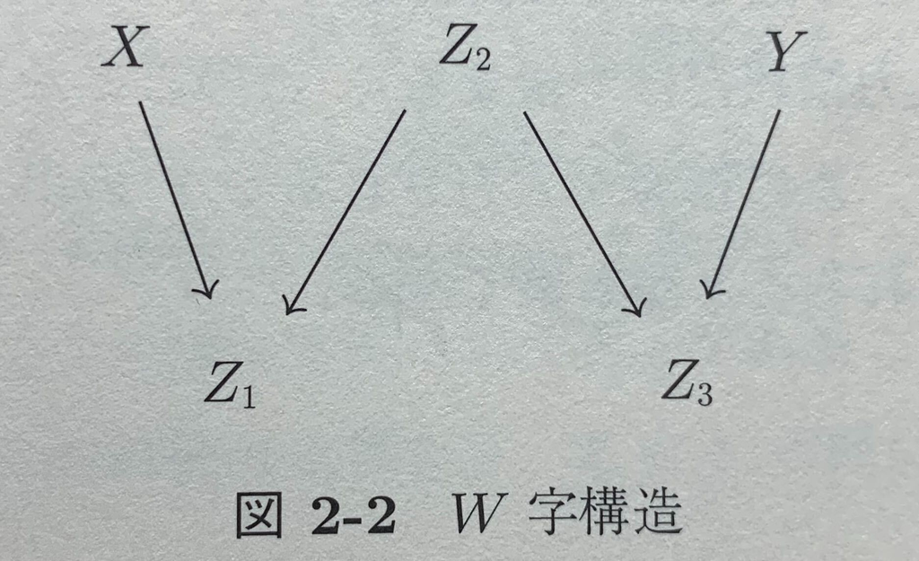

## W字構造（W-structure）の例-2

- まずは空集合を考える
  - 非合流点$Z_2$は空集合に含まれないため、条件2を満たさない
  - 空集合は合流点$Z_1,Z_3$も含んでいないため、条件1を満たす

空集合は $X$ と $Y$ を有向分離する

- $Z_2$を含む頂点集合 $\{Z_2\},\{Z_1,Z_2\},\{Z_2,Z_3\},\{Z_1,Z_2,Z_3\}$を考える
  - 非合流点 $Z_2$ を含むため、条件2を満たす

条件1を満たすかどうかに関係なく、  
$Z_2$を含む頂点集合は$X$と$Y$を有向分離する

## W字構造（W-structure）の例-3

- $\{Z_1\}$を考える
  - $Z_1$ は合流点であり非合流点$Z_2$を含まないため、  
    条件2を満たさない
  - もう1つの合流点$Z_3$は$\{Z_1\}$に含まれないため、  
    条件1を満たす

$\{Z_1\}$は$X$と$Y$を有向分離する  
同様に$\{Z_3\}$も$X$と$Y$を有向分離する

- 興味ある2つの頂点集合の間の道のそれぞれについて、  
  定義2-5の片方の条件を満たすことが分かれば、  
  もう1つの条件を満たすかどうかとは無関係に  
  $X$と$Y$を有向分離すると主張可能

## W字構造（W-structure）の例-4

- $\{Z_1,Z_3\}$を考える
  - 非合流点$Z_2$を含まないため、条件2を満たさない
  - 集合に含まれる$Z_1,Z_3$は合流点であるため、  
    条件1を満たさない

$\{Z_1,Z_3\}$は$X$と$Y$を有向分離しない  
$\{Z_1,Z_3\}$は (2.55) 式で与えられる道を開いている

## 有向分離基準の直感的理解のために

- グラフを1次関数に基づくデータ伝達過程と結びつけて  
  考える
- 有向グラフ上の2つの頂点$X$と$Y$について、  
  $X \rightarrow Y$は$X$の入力情報が決定論的な1次関数

$$Y = \alpha_{yx}X \tag{2.56}$$

で$Y$の出力情報が生成される状況を示すとする  
($\alpha_{yx}$)

## 連鎖経路（chain）

$$X \rightarrow Z \rightarrow Y \;\; (Y = \alpha_{yx}Z,Z = \alpha_{zx}X)$$

は$Z$が$X$と$Y$を有向分離しているケース

- $Y$の出力情報は$Z$の入力情報だけで決まり、  
  $X$の入力情報とは無関係

## 分岐経路（fork）

$$X \leftarrow Z \rightarrow Y \;\; (Y = \alpha_{yx}Z,X = \alpha_{xz}Z)$$

は$Z$が$X$と$Y$を有向分離しているケース

- $X$と$Y$の出力情報は$Z$の入力情報だけで決まる
- $Z$に情報が入力されると、$Y$の出力情報は  
  $X$の出力情報とは無関係

## 合流経路（inverted fork）

$$X \rightarrow Z \leftarrow Y \;\; (Z = \alpha_{zy}Y + \alpha_{zx}X)$$

は空集合が$X$と$Y$を有向分離しているが、  
$Z$は$X$と$Y$を有向分離しないケース

- $X$と$Y$の2つの入力情報に基づいて$Z$の出力情報が  
  生成されるが、$X$と$Y$は無関係
- $X$と$Y$の両方の情報から生成された$Z$の出力情報が  
  $z$であるとき、次の関数関係を得る

$$Y = \frac{z}{\alpha_{zy}}-\frac{\alpha_{zx}X}{\alpha_{zy}} \tag{2.57}$$

- $Z$の出力情報を考慮することで$X$と$Y$は関係を持つ

## 有向分離基準の直感的理解の難しさ1

- $Y$字構造（Y-structure）を例に考える

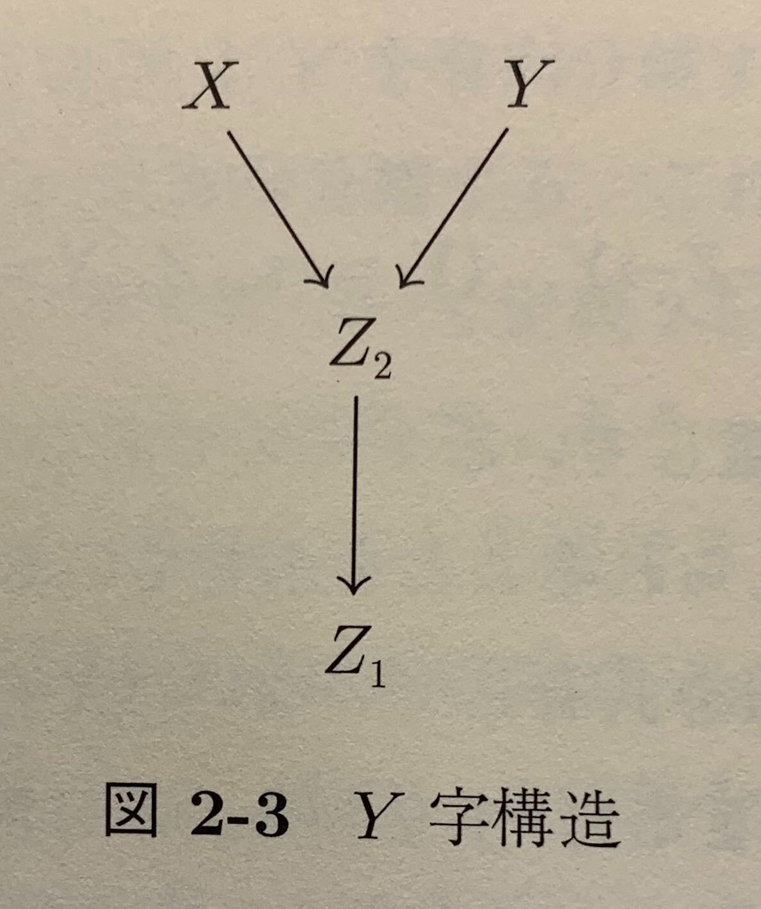

- $X$と$Y$の間に$Z_1$を通る道は存在しないため、  
  $Z_1$は$X$と$Y$を有向分離するように見える
- しかし定義2-5を適用すると、$X$と$Y$は空集合によって  
  有向分離されるが、$Z_1$によって有向分離されなくなる

## 有向分離基準の直感的理解の難しさ2

- $Z_1$の出力情報が$Z_1=z_1$とわかると$Z_2$は、

$$Z_2 = \frac{z_1}{\alpha_{z_1z_2}} \tag{2.58}$$

$$Z_2 = \alpha_{z_2x}X + \alpha_{z_2y}Y \tag{2.59}$$

であることより、

$$\frac{z_1}{\alpha_{z_1z_2}} = \alpha_{z_2x}X + \alpha_{z_2y}Y \tag{2.60}$$

となる

- 合流点と同様の議論より、$Z_1$の出力情報が与えられれば  
  その情報が$Z_2$に引き継がれ、その結果$X$と$Y$は  
  $Z_1$によって有向分離されなくなる

# 2.8 ベイジアンネットワーク

## ベイジアンネットワークの定義

双方向矢線のないDAG $G =$$\bf(\bf V,\bf E)$ が
$\bf V =$$\{X_1,_\cdots,X_p\}$ の同時分布をグラフ $G$ に従う
逐次的因数分解の形、つまり

$$pr(x_1,_\cdots,x_p) = \prod^p_{i=1}pr(x_i|pa(x_i)) \tag{2.61}$$

の形に規定する時、グラフ$G$を**ベイジアンネットワーク**（有向独立グラフ）という  
$pr(x_i|pa(x_i))$は$X_i$の親集合$pa(X_i) = pa(x_i)$を  
与えた時の$X_i$の確率分布であり、  
$pa(X_i)$が空集合の時は$X_i$の周辺分布$pr(x_i)$を表す

## 因果ダイアグラムとの比較

- ベイジアンネットワーク
  - DAGを条件付き独立関係の視覚的表現あるいは  
    同時分布の近似的表現とみなす
- 因果ダイアグラム（詳細は第3章）
  - DAGをデータ生成過程の視覚的表現とみなす
  - 同時分布の良い近似を与えているとは限らない

## ベイジアンネットワークの構成方法1

- 連鎖公式(2.36) 式より、$p$次元同時分布$pr(x_1,_\cdots,x_p)$は  
  任意の順序で逐次的因数分解でき、それぞれに対応する  
  ベイジアンネットワークを構成可能
  - やみくもに同時分布を逐次的因数分解し、  
    ベイジアンネットワークを構成しても統計的独立関係に  
    関する表現能力は低く、  
    視覚的表現は理論的、実用的ともにあまり役に立つものでない $\quad$
- まず、$X_i$の条件付き確率分布$pr(x_i|x_1,_\cdots,x_{i-1})$が  
  $X_1,_\cdots,X_{i-1} \;(i=1,_\cdots,p)$ 全てではなく、  
  ある変数集合$pa(X_i)$によって規定されているとする
  - 仮定: $pa(x_i)$は$X_i$と$pa(X_i)$以外の変数集合  
    $\{X_1,_\cdots,X_{i-1}\}\backslash pa(X_i)$と条件付き独立とするような極小集合

## ベイジアンネットワークの構成方法2

- (2.36) 式の積より、条件付き確率分布はそれぞれ、

$$pr(x_i|x_1,_\cdots,x_{i-1}) = pr(x_i|pa(x_i)) \; i=1,_\cdots,p \tag{2.62}$$

- $X_1,_\cdots,X_{i-1}$を与えたときの$X_i$の確率分布ではなく、 $pa(X_i)$を与えた時の$X_i$の確率分布のみに注目
- $pa(X_i)$をDAGにおける親集合とみなしその各要素から  
  $X_i$へ矢線を引くDAGをベイジアンネットワークとみなす  
  $\quad$
- ベイジアンネットワークの構成方法により  
  次の2つの定理が成立
  - 局所的有向マルコフ性（local directed Markov property）
  - 大域的有向マルコフ性（global directed Markov property）

## 定理2-2 局所的有向マルコフ性

ベイジアンネットワーク$G$において、  
任意の変数$X$に対して、その親集合$pa(X)$を与えた時、  
$X$の親以外の非子孫からなる集合$nd(X)$と$X$は  
条件付き独立  
つまり(2.63) 式の**局所的有向マルコフ性**が成り立つ

$$X\mathop{\,\perp\!\!\!\!\!\perp\,}\bigl(nd(X)\backslash pa(X)\bigr)|pa(X) \tag{2.63}$$

$pa(X)$が空集合の時は$X\mathop{\,\perp\!\!\!\!\!\perp\,}nd(X)$

- 同時分布の条件付き独立関係が局所的有向マルコフ性  
  のみで即座にわかるわけではない（M字構造の例）

## M字構造（M-structure）の例

$$pr(x,y,z_1,z_2,z_3) = pr(y|z_3)pr(z_2|z_1,z_3)pr(x|z_1)pr(z_1)pr(z_3) \tag{2.64}$$

- このとき、局所的有向マルコフ性により

$$X\mathop{\,\perp\!\!\!\!\!\perp\,}\{Z_2,Z_3,Y\}|Z_1,\; Y\mathop{\,\perp\!\!\!\!\!\perp\,}\{Z_1,Z_2,X\}|Z_3\\
Z_2\mathop{\,\perp\!\!\!\!\!\perp\,}\{X,Y\}|\{Z_1,Z_3\},\; Z_1\mathop{\,\perp\!\!\!\!\!\perp\,}Z_3 \tag{2.65}$$

- しかし、

$$X \mathop{\,\perp\!\!\!\!\!\perp\,}Y \tag{2.66}$$

が成立することを直接確かめられず、グラフォイド原理を  
繰り返し適用することで（2.66）式を導く

## 定理2-3 大域的有向マルコフ性

ベイジアンネットワーク$G$において、$\bf Z$が$\bf X$と$\bf Y$を  
有向分離するなら、頂点に対応する確率変数において、  
$\bf Z$を与えた時、$\bf X$と$\bf Y$は条件付き独立  
つまり(2.67) 式の**大域的有向マルコフ性**が成り立つ

$$\bf X \mathop{\,\perp\!\!\!\!\!\perp\,}Y|Z \tag{2.67}$$

- ベイジアンネットワーク$G$において$\bf Z$が$\bf X$と$\bf Y$を  
  有向分離しない時、$\bf X \mathop{\,\perp\!\!\!\!\!/\!\!\!\!\!\perp\,}Y|Z$が成り立つことを  
  述べているわけではない
  - 一般に$\bf X \mathop{\,\perp\!\!\!\!\!/\!\!\!\!\!\perp\,}Y|Z$が成り立つかどうかをグラフ構造からは  
    判断できない

## Y字構造のベイジアンネットワーク1

- 同時分布の逐次的因数分解は

$$pr(x,y,z_1,z_2) = pr(z_1|z_2)pr(z_2|x,y)pr(x)pr(y) \tag{2.68}$$

- この式より

$$Z_1 \mathop{\,\perp\!\!\!\!\!\perp\,}\{X,Y\}|Z_2,\; X \mathop{\,\perp\!\!\!\!\!\perp\,}Y \tag{2.69}$$

- 図を見れば上記の逐次的因数分解を行わなくても
  - $Z_2$は$Z_1$と$\{X,Y\}$を有向分離
  - 空集合が$X$と$Y$を有向分離
- 定理2-3より
  - $Z_2$を与えた時、$Z_1$と$\{X,Y\}$は条件付き独立
  - 空集合$\phi$を与えた時、$X$と$Y$は条件付き独立

## Y字構造のベイジアンネットワーク2

- 連鎖公式(2.36)式は任意の変数順序に対して  
  適用可能であることを利用
- (2.68)式の左辺をあえて以下のように逐次的因数分解

$$pr(x,y,z_1,z_2) = pr(x|y,z_1,z_2)pr(y|z_1,z_2)pr(z_2|z_1)pr(z_1) \tag{2.70}$$

- (2.69)式より定理2-1の弱結合性を用いて

$$Z_1\mathop{\,\perp\!\!\!\!\!\perp\,}X|\{Y,Z_2\} \tag{2.71}$$

- 定理2-1の分解性を用いて

$$Z_1\mathop{\,\perp\!\!\!\!\!\perp\,}Y|Z_2 \tag{2.72}$$

- これらより、 (2.70)式は以下のように書き直せる

$$pr(x,y,z_1,z_2) = pr(x|y,z_2)pr(y|z_2)pr(z_2|z_1)pr(z_1) \tag{2.73}$$

## Y字構造のベイジアンネットワーク3

- (2.73)式よりベイジアンネットワークとみなせる

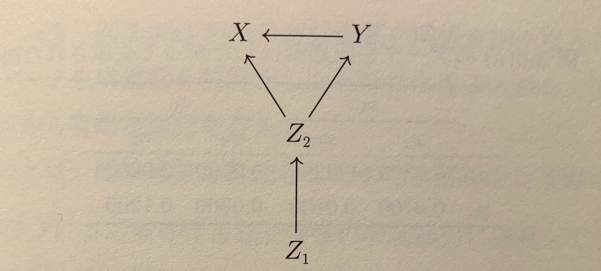

- $Z_2$が$Z_1$と$\{X,Y\}$を有向分離しているため

$$Z_1 \mathop{\,\perp\!\!\!\!\!\perp\,}\{X,Y\}|Z_2 \tag{2.74}$$

は成り立つが、$X \mathop{\,\perp\!\!\!\!\!\perp\,}Y \tag{2.75}$をグラフから読み取れない

- ベイジアンネットワークから導かれる有向分離関係のみ  
  では確率分布によって規定される条件付き独立関係を  
  十分に記述できないケースが存在  
  ➡「︎ベイジアンネットワークを用いて因果関係を  
  記述する際に引き起こされる問題」

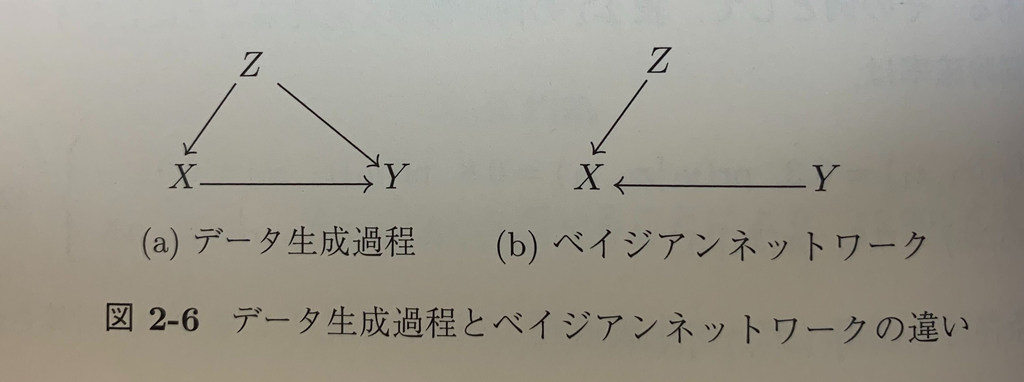

## 因果推論を目的としたデータ解析への警告

1. 有効グラフによる条件付き独立関係の表現能力に  
   固執してしまうと、因果推論を行うのに役立たない  
   ばかりか、誤った解釈を与えるような有向グラフが  
   得られる可能性がある
2. データ生成過程に基づいた有向グラフからは  
   読み取れない条件付き独立関係が存在する可能性が  
   あるため、それに固執してしまうと同時分布の  
   最良近似が得られないケースが起こりうる
- このトレードオフの問題を回避するために  
  **忠実性**（faithfulness）という概念を導入

## 忠実性

同時分布$pr(x_1,_\cdots,x_p)$について、  
ベイジアンネットワーク$G$によって規定される  
有向分離関係以外のいかなる統計的独立関係も  
付加的に成り立っていない時、  
$pr(x_1,_\cdots,x_p)$はグラフ$G$に**忠実**であるという

- 因果構造探索問題を議論する際のほとんどで使用
- 因果効果の識別可能性問題（第3章以降）の  
  議論にも暗黙に使用

## 忠実性の例

- (2.68)式で与えられる同時分布$pr(x,y,z_1,z_2)$から  
  導かれる条件付き独立関係が(2.78)式のみとする

$$Z_1 \mathop{\,\perp\!\!\!\!\!\perp\,}\{X,Y\}|Z_2,\;X \mathop{\,\perp\!\!\!\!\!\perp\,}Y \tag{2.78}$$

- 図2-3から得られる有向分離関係
  - $Z_2$が$Z_1$と$\{X,Y\}$を有向分離
  - 空集合が$X$と$Y$を有向分離
- $pr(x,y,z_1,z_2)$において、図2-3から得られる  
  有向分離関係以外の統計的独立関係が付加的に  
  成り立っていないため、  
  $pr(x,y,z_1,z_2)$は図2-3の有向グラフに忠実

# 2.9 ランダム化

## 実験を行う目的

竹内他（1989）『統計学辞典』  
「諸**原因**系が**結果**の特性値に及ぼす**影響**を解明」

- 実験は因果関係を解明する有力な方法論の1つ

## 偶然誤差と系統誤差

- 系統誤差（systematic error）：  
  何らかの傾向をもった生成メカニズムに基づいて  
  生成される誤差
- 偶然誤差（random error）：  
  系統誤差のような傾向を持たず、処理変数の  
  挙動とは無関係に、偶発的に生成された誤差
- 介入を伴わない観察研究において、
  - 共変量が反応変数のみにしか影響を与えない  
    ➡︎**偶然誤差**とみなし因果効果を評価
  - 共変量が処理変数にも反応変数にも影響を与え、  
    全て観測されているわけではない（1.5節自動車塗装の例）  
    ➡︎**系統誤差**とみなし因果効果の解明が困難

## 実験計画法

取り上げた実験因子が反応変数に与える影響を  
解明するために、効率的で精度の高い実験方法を  
設計し、そのもとで採取されたデータを適切に  
解析する統計解析法の1つ

## Fisherの3原則

1. ランダム化（randomization）  
   共変量の変動を偶然誤差に転化させるために、  
   処理条件を確率的に割り当てる(ランダム割り付け)
2. 反復（replication）  
   データの変動を実験に起因する誤差による部分と  
   それ以外の要因に起因する部分に分離し、誤差分散を 定量的に評価するために、同じ条件下で複数回実験
3. 局所管理（local control）  
   実験の精度向上のため、実験の場を  
   できる限り均一な区間になるように分割

## 完全ランダム化 (complete randomixation)

- 興味の対象となる集団 $n$人
- 処理変数$X$:興味ある$k$個の値（処理条件）$x_1,_\cdots,x_k$
  - $k^n$通りの割り付け（因果関係の解明には不要なものも）
- $n_j$人の個体に処理条件$x_j$を割り当てると$(j=1,\cdots,k)$  
  $M$通り

$$M = \frac{n!}{n_1!\cdots n_k!},\; n = \sum^k_{i=1}n_j \tag{2.81}$$

- $M$個の割り付け方から$1/M$の等確率で1つを選択し、  
  各個体に対して$k$個の処理条件のうちのいずれか1つを  
  与える手続き：**完全ランダム化**
  - $X$と共変量は独立とみなす

## ランダム化実験の例

- $n=4$の集団に対して、$X=x_1,X=x_2$それぞれに  
  対して2人ずつ割り当てる
- このとき$M=4!/2!2!=6$通り(2.82)、つまり

$$(x_1,x_1,x_2,x_2),(x_1,x_2,x_1,x_2),(x_1,x_2,x_2,x_1)\\
(x_2,x_1,x_1,x_2),(x_2,x_1,x_2,x_1),(x_2,x_2,x_1,x_1) \tag{2.83}$$

- このうち1つが1/6の確率で選択され、  
  処理条件が割り当てられる

## 完全ランダム化の適用可能な場合と欠点

- 適用可能な場面
  - $X=x_j$を割り当てる個体の数があらかじめ決まっている場合
- 欠点
  - 最後の1人に割り当てられる値は一意に決まる
    - 割り付けの予見不能性が崩れることによる恣意的な個体選択
    - 交絡バイアスが生じる可能性
    - 完全ランダム化がランダム化としての役割を果たさない
- 割り付けの予見不能性を担保することが  
  ランダム化の役割の1つ

## 単純ランダム化（simple randomization）

- 個体のそれぞれについて、あらかじめ与えられた確率に  
  従って、処理条件を割り当て
- 処理変数$X$の値は個体が持つ共変量情報とは無関係に  
  割り当て（完全ランダム化と同様）  
  ➡︎処理変数と共変量は独立とみなす
- 本書では主に単純ランダム化を想定
- サンプルサイズが
  - 十分に大きければ、処理変数と共変量は独立になることが期待
  - 小さい場合、偶然性によって、個体の属性（年齢・性別など）や各群に割り当てられる人数に偏りが生じることも

## ランダムな交絡（random confounding）

- 偶然性によるランダム化の失敗を**ランダムな交絡**に  
  よる失敗という
- ランダム化の失敗➡︎因果効果の適切な評価が困難
- ランダムな交絡➡︎起こる可能性小さいことが起こった
  - 「ランダムな交絡が生じている場合には、  
    因果効果を適切に評価することが難しい」という立場が大勢
- 本書では断りのない限り、ランダムな交絡は  
  起こっていないとする

## 層別ランダム化(stratified randomization)

1. 解析結果に影響を与えると考える共変量を取り上げる
2. それに基づき集団をいくつかの部分集団に分割  
   （層別:stratification）
3. 部分集団ごとに完全ランダム化や単縦ランダム化を実施
- とり上げた共変量が偏った状態でそれぞれの処理条件に  
  取り入れられることのないように工夫